# The evolution of Coldplay and Metallica’s Music

JH Pretorius

2023-06-17

### Abstract

This report analyzes the artistic evolution of Coldplay and Metallica using Spotify data. Focusing on their studio recordings, it explores key aspects such as album characteristics, industry trends, and the distinction between live and studio performances. The report presents statistical tables and visualizations to provide insights into the longevity and musical progression of these iconic bands.

# Introduction

In the ever-evolving landscape of music, the growth and transformation of artists provide a captivating narrative that resonates with fans and researchers alike. This report analyses the musical evolution of Coldplay and Metallica, two legendary bands that have left an indelible mark on the industry for over two decades. By leveraging Spotify data and focusing on their studio recordings, I delve into intriguing metrics such as popularity, acousticness, danceability, tempo, and energy. Through a blend of insightful analysis and compelling visualizations, I aim to uncover the dynamic shifts and enduring influence of Coldplay and Metallica’s musical evolution.

## Artist evolution over time

Table 1: Summary Statistics for Coldplay and Metallica Albums

(SD = Standard Deviation)

| artist | Average Popularity | SD: Acousticness | SD: Danceability | SD: Tempo | SD: Energy |
| --- | --- | --- | --- | --- | --- |
| Coldplay | 48.89683 | 0.3543308 | 0.1427605 | 27.48615 | 0.2281393 |
| Metallica | 41.14167 | 0.1203752 | 0.1169404 | 27.18705 | 0.1395753 |

During their tenures as A-list artists, both Coldplay and Metallica were both incredibly, and consistently, popular. Coldplay however, was more popular on average during their time as an artist. Looking at some of the metrics based on the characteristics of their music, it would seem that Metallica had a winning formula they were not willing to change. The standard deviation in their music tempo, energy, danceability, and acousticness were relatively small, indicating little difference in musical style accross time. On the other hand, Coldplay exhibit higher deviation in their musical metrics, showing willingness to experiment more with new styles. Particularly, acousticness and energy seems to differ quite dramatically from song to song. This warrants further investigation to determine whether these deviations a driven by new album releases, with more experimental styles.

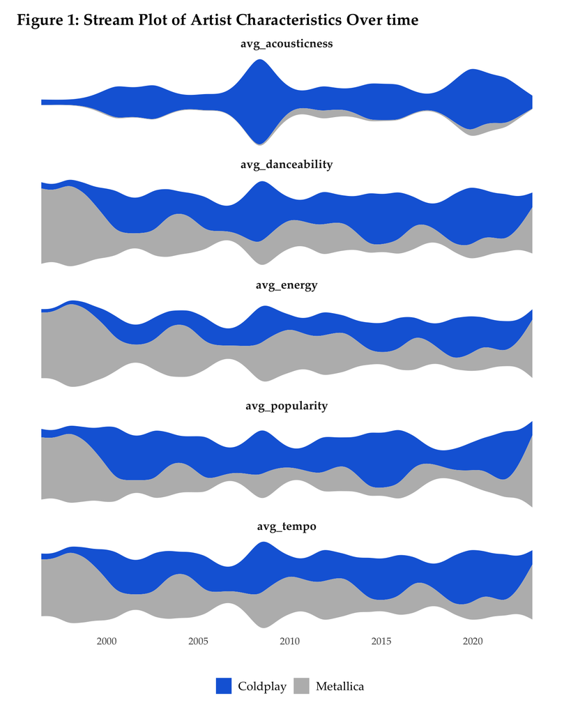

The stream graph visually represents the differences in the artists styles, as compared to one another. The fill colors distinguish between Coldplay and Metallica, with Coldplay depicted in a vibrant blue hue and Metallica in a subtle gray tone. Coldplay’s music is much more acoustically driven, seems to be more danceable, and have higher popularity. On the other hand, Metallica seem to have greater energy in their music.

## Evolution of Album Characteristics

Table 2: Top Albums for Coldplay and Metallica

| album_name | release_date | Popularity | Acousticness | Danceability |
| --- | --- | --- | --- | --- |
| Coldplay |  |  |  |  |
| Ghost Stories | 2014-05-19 | 66.11111 | 0.2851200000 | 0.5085556 |
| Viva La Vida or Death and All His Friends | 2008-05-26 | 23.00000 | 0.9500000000 | 0.4920000 |
| Everyday Life | 2019-11-22 | 18.50000 | 0.5782996667 | 0.4696667 |
| Metallica |  |  |  |  |
| Metallica | 1991-08-12 | 63.91667 | 0.0061460833 | 0.5522500 |
| ...And Justice For All | 1988-08-25 | 55.88889 | 0.0004460556 | 0.5024444 |
| Reload | 1997-11-18 | 44.69231 | 0.0003004000 | 0.4882308 |

Figure 2 visually presents the distribution of song popularity by album for both Coldplay and Metallica, supplying an interesting view of popularity over time for the artists. The boxplots showcase the variation in popularity across albums, with the x-axis representing the album names and the y-axis denoting the popularity score.

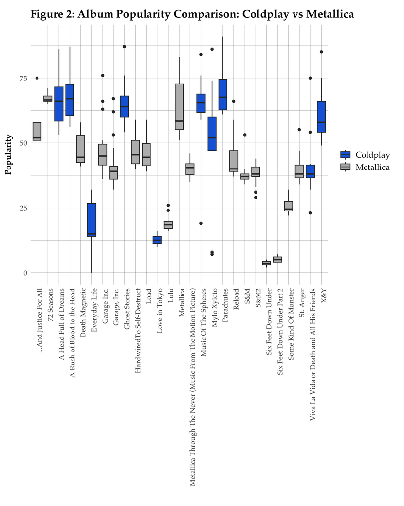

The plot allows us to compare the range and median popularity levels of the albums within each artist’s discography. The differences in popularity patterns between Coldplay and Metallica become apparent, providing valuable insights into the varying dynamics of audience reception and appreciation over the years

## Trends in Music

Figures 3A, 3B, and 3C illustrate the trends in popularity, energy, and acousticness respectively for Coldplay and Metallica over time. Each plot showcases the relationship between the metric and the release date, with different colors representing the two artists. The plots provide valuable insights into how these musical characteristics have evolved for both bands throughout their careers.

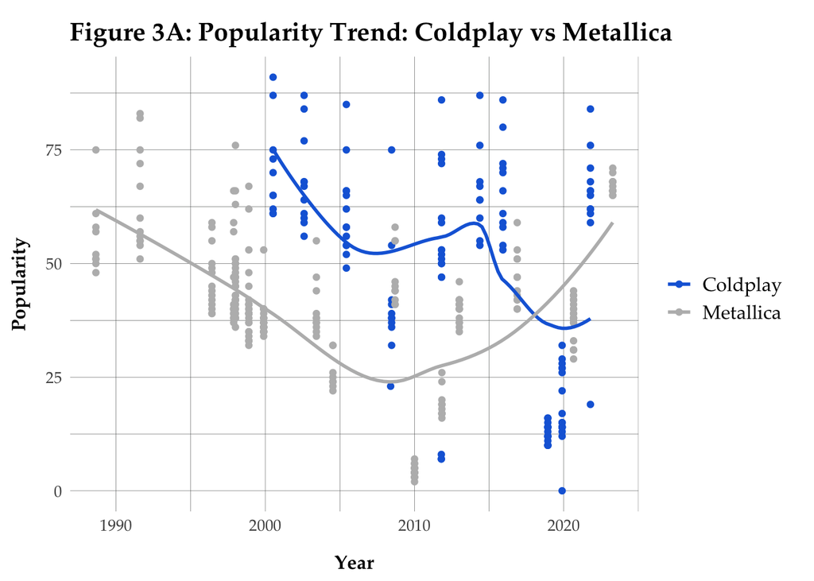

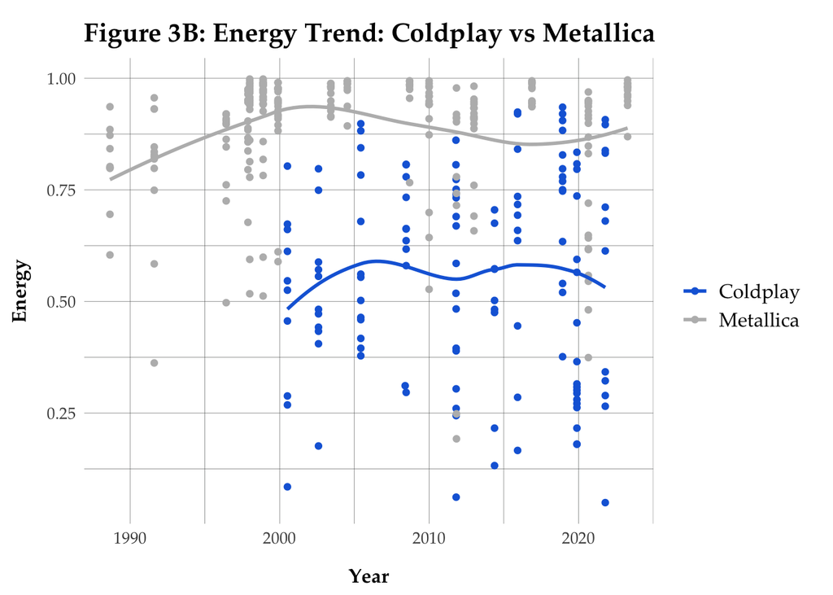

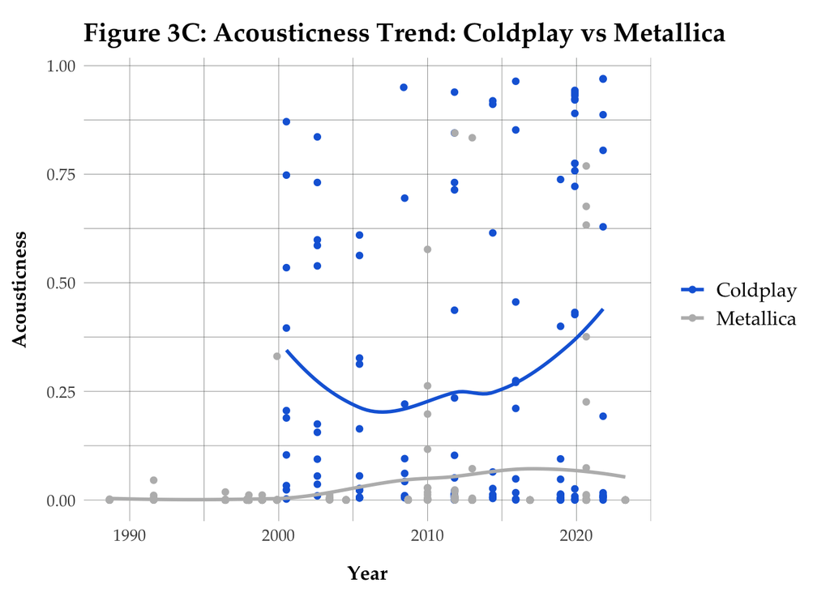

While Colplay is initially more popular then Metallica, their popularity exhibits a clear downward trend over time. This however, is due to the dismal performance of their album ‘Every Day Life’. The release of ‘72 Seasons’ by Metallica was a clear boost to their popularity and projected their popularity higher than Codlplay for the first time.

The energy trend shows consistent energy for both Coldplay and Metallica over time, with Metallica having consistently more energised music than Coldplay.

In terms of acousticness, Metallica remained low, but consistent over time. Coldplay on the other hand show much more variability in the acousticness of their music.

## Live performance vs Studio Recordings

Figures 4 to 7 showcase the distribution of different musical attributes for live and studio versions of songs by Coldplay and Metallica. Each figure focuses on a specific attribute, including popularity, energy, tempo, and danceability. The plots use violins and jittered points to display the distribution of values, with separate panels for each artist. The color palette distinguishes between live and studio versions. These figures provide insights into how these attributes vary between live performances and studio recordings for both bands.

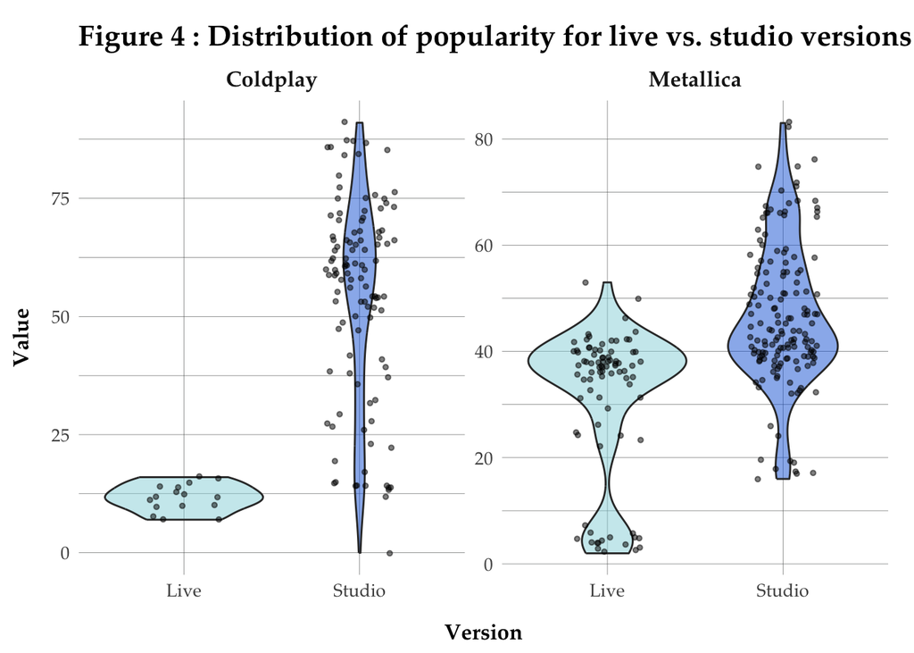

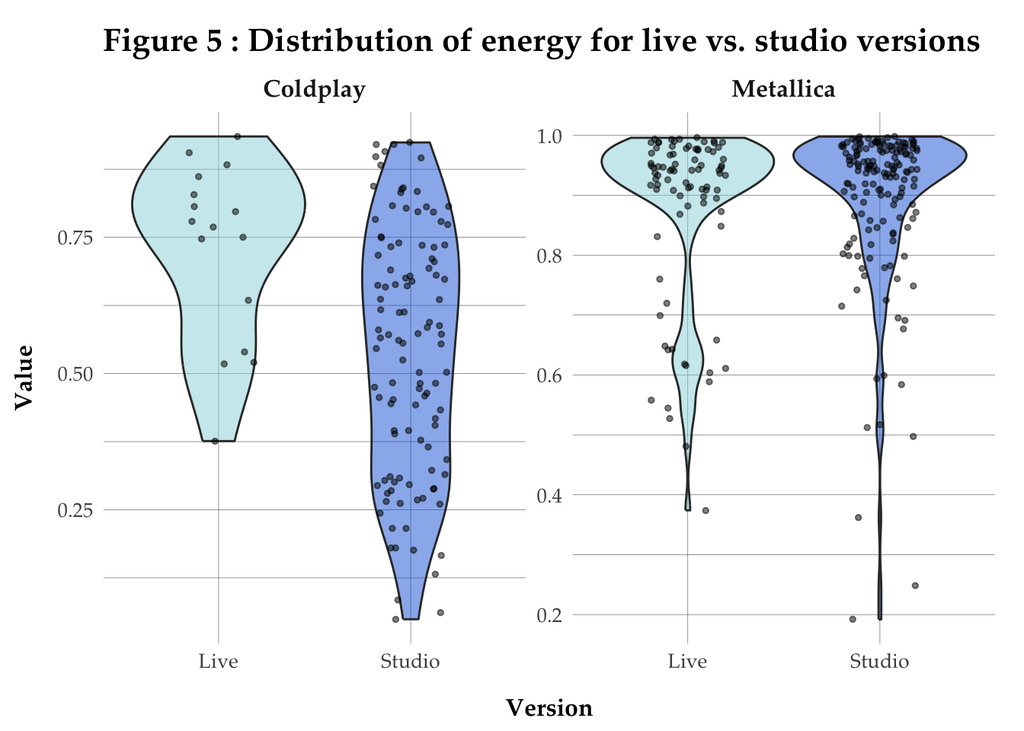

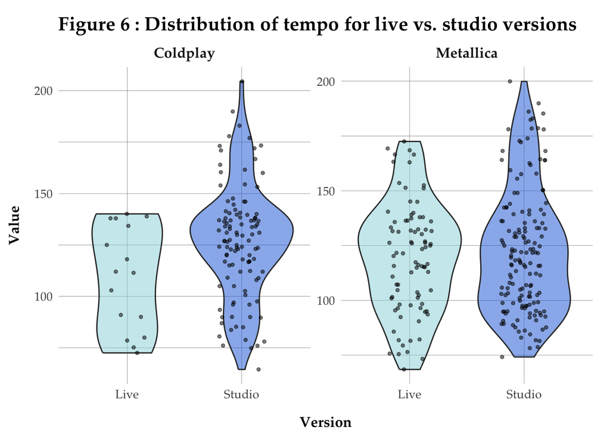

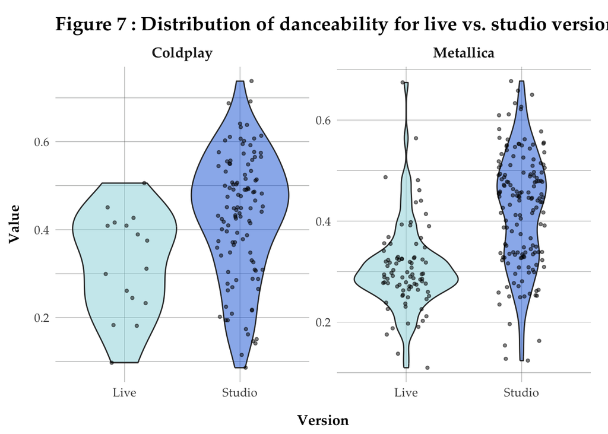

The violin plots reveal interesting differences between live recordings and studio versions for Coldplay and Metallica.

For Coldplay, live recordings are less popular compared to studio versions, while Metallica shows similar levels of popularity in both settings. Coldplay’s live performances exhibit higher energy, while Metallica maintains consistent energy across live and studio music. Surprisingly, Coldplay’s live recordings have lower tempo compared to studio versions, whereas Metallica shows a slight decrease in tempo for live performances. Both bands have more danceable music in their studio recordings, possibly due to the inclusion of electronic and edited sounds that are challenging to reproduce live.

## Conclusion

Moreover, the examination of live recordings showcases interesting distinctions between the two bands. Coldplay’s live versions tend to have lower popularity compared to their studio recordings, while Metallica’s live recordings maintain a similar level of popularity. Additionally, tempo variations are observed, with Coldplay’s live performances featuring a lower tempo compared to their studio versions, adding a unique dimension to their live shows. Similarly, Metallica’s live music exhibits slightly lower tempos, albeit with a relatively small difference.

Overall, the analysis underscores the distinct artistic journeys of Coldplay and Metallica, emphasizing the dynamic nature of their musical interpretations in different performance settings. Coldplay brings vibrant energy to their live shows, while Metallica showcases their instrumental prowess. These findings contribute to a deeper understanding of how these renowned bands have evolved over time, providing valuable insights into their musical styles and performances.